# sro_covid_analyses_supplementary

### Supplemental Figures for *Relating psychiatric symptoms and self-regulation during the COVID-19 crisis*

This notebook contains loadings matrices for Exploratory Factor Analysis conducted on training datasets for:

- Self-regulation tasks
- Self-regulation surveys
- Self-reported psychiatric symptoms
- Corona Health and Impact Survey
- Health Risk Behaviors

```python
import warnings
warnings.filterwarnings('ignore')
warnings.simplefilter('ignore')

import matplotlib.pyplot as plt
import matplotlib as mpl
import seaborn as sns
from selfregulation.utils.result_utils import load_results
from dimensional_structure.EFA_plots import plot_factor_df
```

```python
all_results  = load_results(datafile = 'Covid_train', verbose = False)
```

### Self-regulation tasks Exploratory Factor Analysis Loadings

4 factors were determined using a BIC criteria for exploratory factor analysis. The training dataset was represented by 386 subjects who completed the battery of tasks on self-regulation only before the onset of the pandemic (i.e., 2016) and part of the dataset published by Eisenberg et al., 2019. The 113 variables are grouped and ordered based on the largest (absolute) factor loading for that variable. **However over the cells to see the exact value**

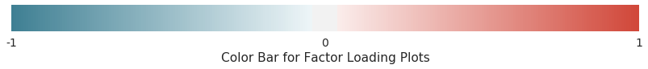

```python
fig = plt.figure(figsize=(12, 3))
ax1 = fig.add_axes([0.05, 0.80, 0.9, 0.15])
cmap = sns.diverging_palette(220,15,n=20, as_cmap=True)
cb1 = mpl.colorbar.ColorbarBase(ax1, cmap=cmap,
                                orientation='horizontal')
cb1.set_ticks([0,.5,1])
cb1.set_ticklabels(['-1','0', '1'])
cb1.set_label('Color Bar for Factor Loading Plots')
```

```python
plot_factor_df(all_results['task'], 'task')
```

|  | Caution | Perception Response | Speeded IP | Strategic IP |
| --- | --- | --- | --- | --- |
| SSRT low (Stop signal) | -0.082 | 0.62 | -0.19 | 0.00025 |
| SSRT high (Stop signal) | -0.053 | 0.6 | -0.2 | -3.4e-05 |
| SSRT (Motor stop signal) | -0.079 | 0.57 | -0.13 | -0.0049 |
| Non decision^ (Motor stop signal) | -0.056 | 0.54 | 0.073 | -0.051 |
| Non decision^ (Stroop) | 0.12 | 0.54 | 0.11 | -0.081 |
| Non decision^ (Simon) | 0.11 | 0.52 | 0.078 | -0.028 |
| Non decision^ (Shape matching) | 0.19 | 0.51 | 0.15 | -0.083 |
| Non decision^ (Attention network) | -0.11 | 0.46 | 0.096 | -0.11 |
| Average RT (Simple reaction time) | 0.16 | 0.45 | -0.42 | -0.023 |
| Non decision^ (Recent probes) | 0.25 | 0.43 | 0.12 | -0.044 |
| Non decision^ (Directed forgetting) | 0.092 | 0.42 | 0.37 | -0.13 |
| Non decision^ (Choice reaction time) | 0.14 | 0.42 | -0.045 | 0.0056 |
| Non decision ^ (Stop signal) | 0.17 | 0.32 | 0.1 | 0.065 |
| Non decision^ (Local global letter) | 0.067 | 0.19 | 0.12 | 0.12 |
| Beta (Shift task) | 0.048 | 0.16 | -0.035 | 0.12 |
| Proactive SSRT speeding (Stop signal) | -0.08 | 0.14 | -0.054 | 0.029 |
| Average card chosen (Columbia card hot) | -0.095 | -0.14 | -0.13 | -0.082 |
| Positive learning bias (Probabilsitic selection) | 0.048 | -0.071 | 0.029 | 0.06 |
| Threshold^ (Attention network) | 0.64 | 0.00034 | 0.076 | -0.0022 |
| Threshold^ (Simon) | 0.6 | 0.12 | -0.14 | -0.017 |
| Threshold^ (Shape matching) | 0.57 | 0.0056 | -0.0026 | 0.058 |
| Threshold^ (Three by two) | 0.56 | 0.1 | -0.19 | 0.093 |
| Threshold^ (Stroop) | 0.5 | -0.045 | 0.076 | -0.076 |
| Threshold^ (Local global letter) | 0.5 | 0.095 | -0.00089 | 0.25 |
| Threshold^ (Choice reaction time) | 0.48 | 0.094 | 0.029 | -0.01 |
| Threshold^ (Motor stop signal) | 0.47 | -0.14 | 0.15 | -0.1 |
| Bias (Go Nogo) | 0.39 | 0.061 | 0.0049 | -0.11 |
| Threshold^ (Directed forgetting) | 0.39 | 0.016 | -0.025 | 0.31 |
| Threshold^ (Stop signal) | 0.37 | -0.12 | 0.18 | -0.2 |
| Threshold^ (Recent probes) | 0.34 | 0.015 | -0.18 | 0.13 |

[output cut: 83 more lines]

### Self-regulation surveys Exploratory Factor Analysis Loadings

8 factors were determined using a BIC criteria for exploratory factor analysis. The training dataset was represented by 386 subjects who completed the battery of surveys on self-regulation only before the onset of the pandemic (i.e., 2016) and part of the dataset published by Eisenberg et al., 2019. The 61 variables are grouped and ordered based on the largest (absolute) factor loading for that variable. **However over the cells to see the exact value**

```python
plot_factor_df(all_results['survey'], 'survey')
```

|  | Agreeableness | Emotional Control | Ethical Risk-Taking | Goal-Directed Mindfulness | Reward Sensitivity | Risk Perception | Sensation Seeking | Social Risk-Taking |
| --- | --- | --- | --- | --- | --- | --- | --- | --- |
| Past negative (Time perspective) | -0.17 | -0.71 | -0.0016 | 0.032 | 0.053 | 0.09 | 0.078 | 0.027 |
| Emotional stability (Ten Item Personality) | 0.0011 | 0.7 | -0.012 | 0.12 | 0.02 | -0.032 | 0.067 | 0.018 |
| BIS (BIS-BAS) | 0.32 | -0.67 | -0.12 | -0.14 | -0.027 | 0.11 | -0.13 | -0.015 |
| Non judgement (Five Facets Mindfulness) | 0.033 | 0.55 | -0.21 | -0.052 | 0.071 | -0.0082 | -0.13 | 0.017 |
| Future time perspective | 0.29 | 0.44 | 0.072 | 0.096 | 0.14 | 0.015 | -0.037 | 0.071 |
| Non reactive (Five Facets Mindfulness) | 0.11 | 0.44 | 0.037 | 0.14 | -0.072 | 0.0032 | 0.06 | 0.14 |
| Negative urgency (UPPS-P) | -0.093 | -0.43 | 0.17 | -0.31 | 0.38 | 0.016 | -0.0062 | 0.038 |
| Emotional eating (3 Factor Eating) | 0.13 | -0.41 | 0.12 | -0.095 | 0.088 | -0.15 | -0.049 | -0.035 |
| Describe (Five Facets Mindfulness) | 0.16 | 0.36 | -0.026 | 0.28 | 0.14 | 0.022 | -0.1 | 0.25 |
| Mindfulness (Mindful Attention Awareness) | 0.094 | 0.35 | -0.24 | 0.35 | -0.03 | -0.019 | -0.076 | 0.05 |
| Uncontrolled eating (3 Factor Eating) | 0.13 | -0.35 | 0.29 | -0.059 | 0.19 | -0.14 | 0.015 | -0.12 |
| Lack of perseverance | -0.027 | 0.0027 | 0.026 | -0.89 | -0.061 | -0.057 | -0.065 | -0.02 |
| Grit (Grit Scale) | -0.12 | 0.17 | -0.085 | 0.81 | 0.087 | 0.012 | 0.016 | -0.044 |
| Future (Time perspective) | 0.14 | -0.25 | 0.067 | 0.75 | -0.24 | 0.08 | -0.016 | 0.014 |
| Conscientiousness (Ten Item Personality) | 0.029 | 0.016 | -0.051 | 0.73 | -0.057 | 0.025 | 0.014 | -0.02 |
| Control (Self-regulation) | 0.15 | 0.26 | -0.036 | 0.68 | -0.028 | 0.082 | -0.017 | 0.13 |
| Act with awareness (Five Facets Mindfulness) | 0.0063 | 0.25 | -0.22 | 0.56 | 0.054 | -0.017 | -0.021 | 0.0013 |
| Selection optimization compensation .optimization | 0.042 | 0.16 | 0.06 | 0.54 | -0.093 | 0.022 | 0.045 | 0.046 |
| Self-control (Brief Self-Control Scale) | 0.066 | 0.32 | -0.17 | 0.53 | -0.24 | 0.078 | 0.072 | -0.07 |
| Selection optimization compensation .elective selection | -0.084 | 0.039 | 0.074 | 0.5 | -0.033 | 0.038 | -0.15 | -0.15 |
| Lack of premeditation (UPPS-P) | -0.3 | 0.27 | 0.0069 | -0.5 | 0.38 | -0.044 | 0.08 | -0.0029 |
| Control (MPQ) | 0.16 | 0.076 | 0.08 | 0.44 | -0.42 | -0.0057 | -0.058 | -0.18 |
| Selection optimization compensation .compensation | 0.18 | 0.083 | 0.058 | 0.35 | -0.023 | 0.041 | -0.038 | 0.069 |
| Endorse limited resource (Willpower) | 0.18 | -0.22 | 0.12 | -0.32 | 0.082 | -0.022 | -0.092 | -0.18 |
| Observe (Five Facets Mindfulness) | 0.21 | -0.11 | 0.0047 | 0.25 | 0.087 | 0.15 | -0.0011 | 0.23 |
| BAS reward responsiveness (BIS-BAS) | 0.48 | -0.14 | 0.037 | 0.2 | 0.42 | 0.097 | 0.0078 | 0.077 |
| Past positive (Time perspective) | 0.42 | 0.16 | 0.054 | 0.14 | 0.21 | 0.018 | -0.083 | -0.21 |
| Agreeableness (Ten Item Personality) | 0.41 | 0.16 | -0.26 | 0.07 | 0.11 | 0.061 | 0.045 | -0.15 |
| Boredom susceptibility (Sensation Seeking) | -0.36 | -0.027 | 0.21 | 0.076 | 0.22 | -0.096 | 0.095 | 0.18 |
| Reappraisal (Emotion Regulation) | 0.33 | 0.27 | 0.071 | 0.097 | 0.08 | 0.072 | 0.1 | 0.097 |
| Ethical (RP) (DOSPERT) | 0.046 | 0.01 | -0.24 | -0.0064 | 0.021 | 0.78 | 0.042 | 0.028 |
| Health safety (RP) (DOSPERT) | 0.066 | -0.074 | -0.11 | 0.081 | 0.032 | 0.76 | -0.064 | 0.018 |
| Recreation (RP) (DOSPERT) | -0.099 | -0.016 | 0.12 | 0.047 | 0.06 | 0.67 | -0.37 | 0.084 |
| Social (RP) (DOSPERT) | -0.037 | 0.039 | 0.36 | -0.031 | -0.046 | 0.61 | 0.038 | -0.36 |
| Financial (RP) (DOSPERT) | -0.094 | -0.2 | -0.17 | 0.17 | 0.0036 | 0.45 | 0.028 | 0.04 |
| Cognitive restraint (3 Factor Eating) | 0.098 | -0.055 | 0.046 | 0.099 | -0.057 | 0.15 | 0.03 | 0.043 |
| Present hedonistic (Time perspective) | 0.086 | 0.018 | -0.0068 | -0.12 | 0.76 | 0.0016 | 0.22 | 0.037 |
| Impulsiveness (Impulsive-Venturesome) | -0.18 | -0.17 | 0.049 | -0.18 | 0.62 | 0.084 | 0.12 | 0.056 |
| BAS fun seeking (BIS-BAS) | 0.13 | 0.018 | 0.021 | -0.12 | 0.6 | -0.0028 | 0.35 | 0.11 |
| BAS drive (BIS-BAS) | 0.08 | 0.086 | 0.31 | 0.48 | 0.48 | 0.024 | 0.061 | -0.027 |
| Extraversion (Ten Item Personality) | 0.00085 | 0.33 | -0.023 | 0.17 | 0.44 | -0.038 | 0.023 | -0.05 |
| Suppression (Emotion Regulation) | -0.25 | -0.097 | 0.24 | -0.078 | -0.38 | 0.078 | 0.27 | -0.11 |
| Functional (Dickman's Impulsivity inventory) | -0.2 | 0.29 | 0.038 | 0.21 | 0.37 | 0.00094 | 0.16 | 0.12 |
| Present fatalistic (Time perspective) | -0.18 | -0.27 | -0.051 | -0.22 | 0.34 | 0.074 | 0.032 | -0.24 |
| Openness (Ten Item Personality) | 0.014 | 0.12 | -0.083 | 0.097 | 0.3 | 0.1 | 0.22 | 0.26 |
| Selection optimization compensation .loss based selection | 0.12 | -0.049 | 0.088 | 0.14 | -0.21 | 0.084 | -0.12 | 0.12 |
| Thrill aventure seeking (Sensation Seeking) | -0.011 | -0.021 | -0.024 | 0.047 | -0.014 | -0.043 | 0.92 | -0.018 |
| Venturesomeness (Impulsive-Venturesome) | -0.058 | 0.033 | -0.039 | 0.039 | 0.11 | -0.027 | 0.87 | 0.015 |
| Recreation (RT) (DOSPERT) | 0.013 | -0.028 | 0.0006 | 0.017 | -0.099 | -0.071 | 0.84 | 0.062 |
| Sensation seeking (UPPS-P) | -0.033 | 0.034 | 0.051 | 0.059 | 0.18 | -0.04 | 0.84 | -0.018 |
| Recreation (EB) (DOSPERT) | 0.12 | -0.055 | 0.082 | -0.093 | -0.11 | 0.082 | 0.73 | 0.12 |
| Experience seeking (Sensation Seeking) | -0.04 | 0.012 | 0.059 | -0.12 | 0.066 | 0.022 | 0.36 | 0.34 |
| Social (RT) (DOSPERT) | -0.055 | -3.4e-05 | -0.022 | 0.001 | -0.017 | -0.04 | 0.038 | 0.82 |
| Social (EB) (DOSPERT) | 0.056 | 0.036 | 0.17 | -0.071 | -0.052 | 0.13 | 0.066 | 0.61 |
| Ethical (EB) (DOSPERT) | 0.019 | -0.029 | 0.63 | 0.011 | -0.032 | -0.2 | 0.033 | -0.0083 |
| Ethical (RT) (DOSPERT) | -0.18 | -0.11 | 0.58 | 0.016 | 0.091 | -0.27 | -0.044 | 0.077 |
| Financial (EB) (DOSPERT) | 0.16 | 0.17 | 0.51 | -0.22 | -0.14 | 0.021 | 0.15 | 0.026 |
| Health safety (EB) (DOSPERT) | -0.053 | 0.068 | 0.44 | -0.11 | 0.041 | -0.14 | 0.15 | 0.017 |
| Financial (RT) (DOSPERT) | 0.081 | 0.26 | 0.37 | -0.12 | -0.004 | -0.02 | 0.29 | -0.021 |
| Health safety (RT) (DOSPERT) | -0.19 | -0.1 | 0.34 | -0.019 | 0.12 | -0.24 | 0.12 | 0.22 |
| Sensation seeking .disinhibition | -0.0011 | -0.083 | 0.27 | -0.04 | 0.24 | -0.09 | 0.27 | 0.16 |

### Self-reported psychiatric symptoms Exploratory Factor Analysis Loadings

To obtain a factorial solution for transdiagnostic psychiatric dimensions, we took advantage of publicly available data (N = 497) collected by independent researchers using the same psychiatric questionnaires we included in our study (Rouault et al., 2018). We extracted 3 factors to obtain transdiagnostic dimensions of psychiatric symptoms as previous studies found that a model with three underlying factors (labelled anxious-depression, compulsive behavior and intrusive thought, and social withdrawal) provided the best account of the covariance for the dataset used here according to the Cattell’s criterion (Rouault et al., 2018). The 207 variables are grouped and ordered based on the largest (absolute) factor loading for that variable. **However over the cells to see the exact value**

```python
plot_factor_df(all_results['psych'], 'psych')
```

|  | Anxious Depressed | Compulsive Intrusive Thoughts | Social Withdrawal |
| --- | --- | --- | --- |
| Center of attention (LSAS) | 0.048 | -0.051 | 0.78 |
| Talking with people (LSAS) | 0.034 | 0.035 | 0.77 |
| Speaking at meeting (LSAS) | 0.038 | -0.0027 | 0.77 |
| Meeting strangers (LSAS) | 0.082 | -0.00041 | 0.76 |
| Going to a party (LSAS) | 0.11 | -0.01 | 0.72 |
| Giving report to a group (LSAS) | 0.038 | -0.057 | 0.72 |
| Expressing disagreement (LSAS) | 0.02 | -0.018 | 0.67 |
| Entering a room when others already seated (LSAS) | -0.058 | 0.14 | 0.66 |
| Participating in small groups (LSAS) | 0.15 | 0.01 | 0.66 |
| Giving a party (LSAS) | 0.061 | -0.0064 | 0.64 |
| Acting in front of audience (LSAS) | 0.036 | -0.028 | 0.62 |
| Calling someone don't know (LSAS) | 0.052 | 0.11 | 0.62 |
| Working while being observed (LSAS) | 0.054 | 0.16 | 0.57 |
| Resisting salesperson (LSAS) | 0.016 | 0.064 | 0.53 |
| Dread going into a room by yourself (SSS) | 0.14 | 0.09 | 0.53 |
| Returning goods (LSAS) | 0.039 | 0.096 | 0.52 |
| Writing while being observed (LSAS) | -0.0029 | 0.1 | 0.52 |
| Looking at peopl in the eyes (LSAS) | 0.072 | 0.12 | 0.52 |
| Telephoning in public (LSAS) | 0.025 | 0.18 | 0.52 |
| Eating in public (LSAS) | 0.048 | 0.15 | 0.49 |
| Pick up someone (LSAS) | 0.094 | 0.098 | 0.48 |
| Drinking in publich (LSAS) | 0.018 | 0.0037 | 0.48 |
| Talking to authority (LSAS) | 0.2 | 0.1 | 0.46 |
| (Don't) Like mixing with people (SSS) | 0.23 | -0.16 | 0.45 |
| Prefer watching television (SSS) | 0.11 | -0.018 | 0.39 |
| Taking a test (LSAS) | 0.094 | 0.028 | 0.33 |
| Getting together with friends is (not) important to me (AES) | 0.27 | -0.093 | 0.32 |
| Drink containing alcohol (AUDIT) | 0.06 | 0.17 | -0.31 |
| Difficulty in following a conversation (SSS) | 0.16 | 0.23 | 0.3 |
| Six or more dringks in one occasion (AUDIT) | 0.091 | 0.28 | -0.29 |

[output cut: 177 more lines]

### Corona Health and Impact Survey Exploratory Factor Analysis Loadings

We used a large pool of available data (N = 2868) (Nikolaidis et al., 2021) to derive a factorial solution of the Corona Health and Impact Survey (CRISIS) aimed at investigating several aspects related to the emergence of the pandemic such as worries related to COVID-19 or the subjective impact of life changes associated to it. 10 factors were determined using a BIC criteria for exploratory factor analysis. The 37 variables are grouped and ordered based on the largest (absolute) factor loading for that variable. **However over the cells to see the exact value**

```python
plot_factor_df(all_results['crisis'], 'crisis')
```

|  | COVID-19 Worries | Changes Relationship | Economic Concern | General Anxiety | Media Usage | Negative Mood | Physical Exercise | Sleep Hours | Sleep time | Stress Life Changes |
| --- | --- | --- | --- | --- | --- | --- | --- | --- | --- | --- |
| Generally worried | 0.25 | -0.015 | 0.12 | 0.53 | 0.046 | 0.13 | -0.015 | -0.013 | -0.014 | 0.091 |
| Relaxed vs. anxious | 0.029 | 0.0084 | 0.023 | 0.47 | 0.063 | 0.38 | -0.037 | -0.022 | -0.0052 | 0.035 |
| Enjoy usual activities | 0.022 | 0.12 | 0.042 | -0.24 | -0.14 | -0.1 | 0.095 | 0.043 | 0.0082 | -0.16 |
| Fatigued or tired | 0.062 | 0.015 | 0.00025 | -0.038 | -0.0089 | 0.75 | -0.038 | -0.056 | -0.0048 | -0.032 |
| Irritable / angered | 0.011 | -0.071 | 0.026 | -0.034 | 0.047 | 0.67 | 0.019 | 0.031 | -0.023 | 0.069 |
| Able to concentrate / focus | -0.033 | 0.022 | 0.024 | 0.043 | 0.062 | 0.65 | -0.014 | 0.032 | 0.034 | 0.029 |
| Negative thoughts | 0.022 | -0.07 | 0.078 | 0.22 | -0.064 | 0.58 | 0.037 | 0.016 | 0.05 | -0.036 |
| Fidgety / restless | -0.0035 | 0.036 | 0.038 | 0.1 | 0.11 | 0.56 | -0.0022 | 0.0083 | -0.025 | 0.11 |
| Lonely | -0.067 | -0.11 | 0.024 | 0.019 | 0.071 | 0.45 | -0.019 | 0.024 | 0.082 | 0.16 |
| Happy vs. sad | 0.0093 | -0.058 | -0.006 | 0.023 | 0.061 | 0.075 | -0.012 | -0.013 | 0.0003 | 0.036 |
| Worried about becoming infected | 0.89 | -0.0078 | 0.023 | 0.02 | 0.0026 | -0.07 | -0.013 | 0.0033 | -0.014 | 0.014 |
| Worried family/friends infected | 0.76 | 0.0099 | -0.012 | 0.084 | 0.0049 | -0.018 | 0.008 | 0.0059 | 0.037 | -0.021 |
| Worried about physical health | 0.75 | 0.0042 | 0.011 | -0.1 | 0.0093 | 0.13 | -0.0025 | -0.012 | -0.0028 | 0.016 |
| Worried about mental health | 0.37 | 0.054 | 0.032 | 0.11 | 0.078 | 0.26 | -0.016 | 0.017 | 0.0079 | 0.2 |
| Reading about COVID-19 | 0.28 | 0.068 | -0.057 | 0.21 | 0.063 | -0.096 | 0.069 | -0.023 | 0.0039 | 0.099 |
| Stressed changes in social contacts | -0.016 | -0.054 | 0.013 | -0.023 | 0.0015 | 0.036 | -0.01 | 0.013 | 0.031 | 0.76 |
| Stressed stay at home restrictions | 0.067 | 0.016 | 0.0069 | 0.1 | 0.044 | -0.021 | -0.003 | 0.0019 | -0.0039 | 0.63 |
| Stressed changes in family contacts | 0.082 | -0.13 | 0.056 | -0.018 | 0.017 | 0.044 | 0.0011 | -0.042 | -0.044 | 0.6 |
| Difficulty in following social distance | -0.0017 | 0.063 | 0.013 | -0.042 | -0.079 | 0.0088 | -0.022 | 0.0081 | -0.0043 | 0.56 |
| Difficulty cancellation of important events | -0.061 | 0.085 | 0.058 | 0.05 | 0.078 | -0.036 | 0.068 | 0.022 | 0.0075 | 0.5 |
| Changes in contacts with people | 0.061 | 0.14 | 0.049 | -0.1 | 0.055 | 0.016 | 0.021 | 0.014 | 0.023 | 0.17 |
| Time on social medial | -0.0051 | 0.056 | -0.00073 | -0.041 | 0.65 | 0.038 | -0.0057 | -0.0055 | -0.0012 | 0.033 |
| Time of tv media | 0.044 | -0.13 | 0.011 | 0.065 | 0.48 | -0.065 | -0.02 | 0.026 | 0.068 | -0.11 |
| Time videogames | -0.068 | -0.1 | 0.11 | -0.037 | 0.17 | 0.024 | -0.12 | 0.089 | 0.17 | -0.073 |
| Concerned about living situation | 0.0034 | 0.011 | 0.91 | 0.017 | -0.029 | -0.014 | -0.00086 | 0.0019 | -0.00073 | -0.025 |
| COVID-19, economic difficulty | -0.014 | -0.0058 | 0.71 | -0.054 | 0.052 | 0.017 | 0.002 | -0.0092 | 0.0075 | 0.067 |
| Bed time (weekends) | 0.0098 | 0.0094 | -0.013 | -0.0099 | -0.016 | 0.0041 | 0.0062 | -0.0024 | 1 | 0.013 |
| Bed time (weekdays) | -0.0072 | -0.0086 | 0.021 | 0.0068 | 0.024 | -0.0078 | -0.01 | -0.00038 | 0.89 | -0.016 |
| Sleep hours (weekdays) | -0.00071 | -0.011 | 0.024 | -0.0024 | 0.0052 | -0.013 | 0.0028 | 0.97 | -0.03 | -0.016 |
| Sleep hours (weekends) | 0.008 | 0.015 | -0.036 | 3e-05 | -0.0093 | 0.022 | -0.0072 | 0.87 | 0.037 | 0.021 |
| Quality family relationships | -0.00064 | 0.59 | 0.011 | 0.022 | -0.016 | -0.014 | -0.032 | 0.0014 | 0.0078 | -0.03 |
| Quality friends relationships | 0.012 | 0.42 | 0.049 | -0.025 | 0.083 | -0.0058 | -0.013 | -0.014 | -0.011 | -0.13 |
| COVID-19, positive changes | 0.056 | 0.35 | -0.049 | -0.034 | -0.027 | 0.029 | 0.17 | 0.017 | -0.0079 | -0.026 |
| Hopeful COVID-19 end | -0.12 | 0.16 | 0.033 | -0.064 | 0.071 | -0.1 | -0.0053 | 0.0063 | -0.019 | 0.14 |
| Time outdoors | 0.019 | -0.024 | 0.01 | -0.012 | 0.0098 | 0.02 | 0.9 | -0.005 | -0.01 | -0.051 |
| Time spent outside | -0.063 | -0.00089 | -0.011 | 0.0083 | -0.045 | -0.011 | 0.61 | -0.015 | 0.015 | 0.11 |
| Exercise | -0.015 | 0.12 | -0.041 | 0.04 | 0.011 | -0.072 | 0.51 | 0.034 | -0.0081 | 0.1 |

### Health Risk Behaviors

```python
plot_factor_df(all_results['task'], 'task', DA = True)
```

|  | Binge Drinking | Daily Smoking | Drug Use | Lifetime Smoking | Mental Health | Problem Drinking |
| --- | --- | --- | --- | --- | --- | --- |
| Alcoholhowoften6drinks | 0.88 | 0.038 | -0.007 | 0.024 | 0.02 | 0.034 |
| Alcoholhowmanydrinksday | 0.65 | 0.019 | -0.011 | 0.12 | 0.05 | 0.051 |
| Alcoholhowoften | 0.59 | 0.023 | 0.039 | -0.021 | -0.1 | 0.11 |
| Highesteducation | 0.19 | -0.016 | 0.00011 | -0.097 | -0.034 | -0.023 |
| Heightinches | 0.16 | 0.041 | 0.055 | -0.053 | 0.0013 | -0.13 |
| Weightpounds | 0.16 | -0.088 | -0.061 | 0.0074 | 0.09 | -0.15 |
| Rentown | -0.14 | 0.024 | -0.054 | 0.0052 | -0.042 | 0.089 |
| Divorcecount | -0.13 | -0.0078 | -0.0028 | 0.11 | 0.023 | 0.012 |
| Howoftendrinkmorning | -0.13 | 0.065 | 0.0063 | -0.0088 | 0.0086 | 0.87 |
| Howoftenfailedactivitiesdrinking | 0.04 | -0.04 | -0.017 | 0.054 | -0.01 | 0.85 |
| Howoftencantstopdrinking | 0.15 | 0.0098 | -0.029 | -0.0098 | -0.00045 | 0.77 |
| Howoftenguiltremorsedrinking | 0.27 | 0.058 | 0.082 | -0.14 | 0.027 | 0.59 |
| Howoftenunablerememberdrinking | 0.31 | -0.07 | 0.032 | 0.033 | 0.0072 | 0.48 |
| Relativefriendconcerneddrinking | 0.12 | -0.015 | 0.26 | 0.21 | 0.074 | 0.31 |
| Injureddrinking | 0.14 | -0.077 | 0.22 | 0.21 | 0.096 | 0.3 |
| Abletostopdrugs | 0.21 | -0.02 | -0.2 | 0.054 | 0.0097 | -0.25 |
| Arrestedchargedlifecount | -0.061 | 0.06 | 0.21 | 0.17 | 0.035 | 0.23 |
| Lifetimesmoke100cigs | 0.016 | -0.021 | 0.014 | 0.96 | -0.00051 | -0.0099 |
| Howlongsmoked | 0.022 | 0.21 | -0.013 | 0.76 | 0.0026 | 0.0091 |
| Relationshipnumber | 0.18 | -0.051 | 0.11 | 0.27 | -0.098 | -0.041 |
| Trafficaccidentslifecount | 0.053 | -0.045 | 0.021 | 0.17 | -0.00049 | 0.017 |
| Longestrelationship | 0.058 | -0.12 | -0.075 | 0.15 | -0.1 | 0.0016 |
| Childrennumber | -0.09 | 0.071 | -0.059 | 0.14 | -0.091 | 0.011 |
| Caffienatedsodacansperday | -0.11 | 0.0059 | 0.071 | 0.11 | 0.085 | -0.03 |
| Cigsperday | -0.026 | 0.94 | 0.0076 | -0.035 | 0.0087 | 0.0094 |
| Smokeeveryday | 0.023 | 0.92 | 0.011 | 0.1 | 0.0029 | -0.014 |
| Howsoonsmokeafterwaking | 0.067 | 0.7 | -0.02 | 0.0075 | -0.039 | 0.058 |
| Coffeecupsperday | 0.097 | 0.22 | 0.15 | 0.05 | 0.076 | -0.13 |
| Retirementaccount | 0.03 | -0.18 | -0.013 | 0.14 | -0.11 | 0.02 |
| Householdincome | 0.021 | -0.18 | -0.054 | 0.087 | -0.16 | 0.072 |
| Engagedinillegalactstoobtaindrugs | 0.068 | 0.023 | 0.77 | 0.0011 | -0.0041 | -0.099 |
| Widthdrawalsymptoms | -0.081 | 0.023 | 0.75 | 0.041 | -0.026 | 0.039 |
| Feelbadguiltydruguse | -0.033 | 0.062 | 0.74 | 0.016 | 0.049 | -0.005 |
| Spouseparentscomplaindruguse | 0.0091 | -0.044 | 0.74 | -0.06 | -0.01 | 0.011 |
| Abusemorethanonedrugatatime | 0.016 | -0.061 | 0.71 | -0.0021 | -0.018 | 0.03 |
| Gamblingproblem | -0.073 | 0.067 | 0.31 | 0.045 | 0.11 | 0.19 |
| Cannabispast6months | 0.19 | 0.099 | 0.22 | 0.04 | -0.029 | -0.12 |
| Caffieneothersourcesdaymg | -0.1 | -0.09 | 0.13 | 0.12 | 0.03 | 0.022 |
| Trafficticketslastyearcount | -0.042 | 0.12 | 0.13 | -0.02 | 0.066 | 0.085 |
| Teacupsperday | -0.054 | -0.046 | 0.072 | 0.057 | 0.0034 | -0.052 |
| Depressed | -0.0043 | -0.042 | 0.0061 | -0.0073 | 0.89 | 0.03 |
| Hopeless | 0.041 | 0.035 | 0.012 | -0.021 | 0.88 | -0.084 |
| Worthless | 0.011 | 0.021 | -0.0071 | 0.029 | 0.87 | 0.018 |
| Everythingiseffort | -0.093 | -0.04 | -0.056 | 0.05 | 0.8 | 0.071 |
| Nervous | 0.0017 | 0.06 | 0.042 | -0.086 | 0.67 | -0.014 |
| Restlessfidgety | 0.041 | -0.049 | 0.029 | 0.028 | 0.65 | 0.0026 |
| Last30daysusual | 0.091 | 0.063 | -0.016 | -0.13 | 0.4 | -0.11 |
| Relationshipstatus | 0.098 | -0.074 | -0.043 | 0.093 | -0.19 | 0.04 |